# Data Replication Assignment using Gelfand et al. 2021

Ajna F. Kertesz

4/13/2022

## Briefly about the project

This project is aimed at replicating the major findings of Gelfand et al. 2021 using open access data on COVID-19, as well as CTL scores by countries.

The original cross-national analysis used Cultural Tightness Looseness (CTL) Scores to predict COVID-19 cases and death. Previous studies indicate that there is a large between-country variation in CTL scores. Some countries are more “tight”, which means they have more norms in their society and they follow these norms more closely, while other countries are more “loose”, with less norms and expectations in their society. The COVID-19 pandemic presented an interesting situation, where norm conformity and compliance with new norms and health recommendations (e.g., mask-wearing, social distancing…etc) became a direct predictor of infection and death rates. Therefore, Gelfand and her colleges were interested in investigating whether traditionally tighter countries did indeed have lower infection and death rates.

First they ran simple correlations between centered CTL scores and infection and death rates. They graphed the line of best fit for these two correlation. Next, they used ordinary least squares regression models where CTL was used as a predictor of COVID-19 infection rates. After this, they ran a second regression using CTL as a predictor of COVID-19 death rates. In both models, they adjusted for a number of covariaties including GINI, population density, power distance, local stay-at-home mandates…etc.

Below, I am replicating these models and plots.

## Reproducing Figue 1

The association of cultural tightness and logged cases per million (Oct 2020) *the scatterplot doesn’t include any covariates

### Original figure 1

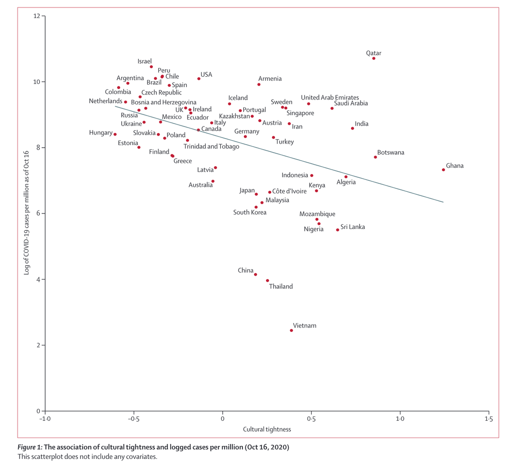

### Reproduced Figure 1

```
##
##  Pearson's product-moment correlation
##
## data:  data$ZTightness and data$OCTCases
## t = -3.2917, df = 55, p-value = 0.001743
## alternative hypothesis: true correlation is not equal to 0
## 95 percent confidence interval:
##  -0.6025560 -0.1622688
## sample estimates:
##        cor
## -0.4056833
```

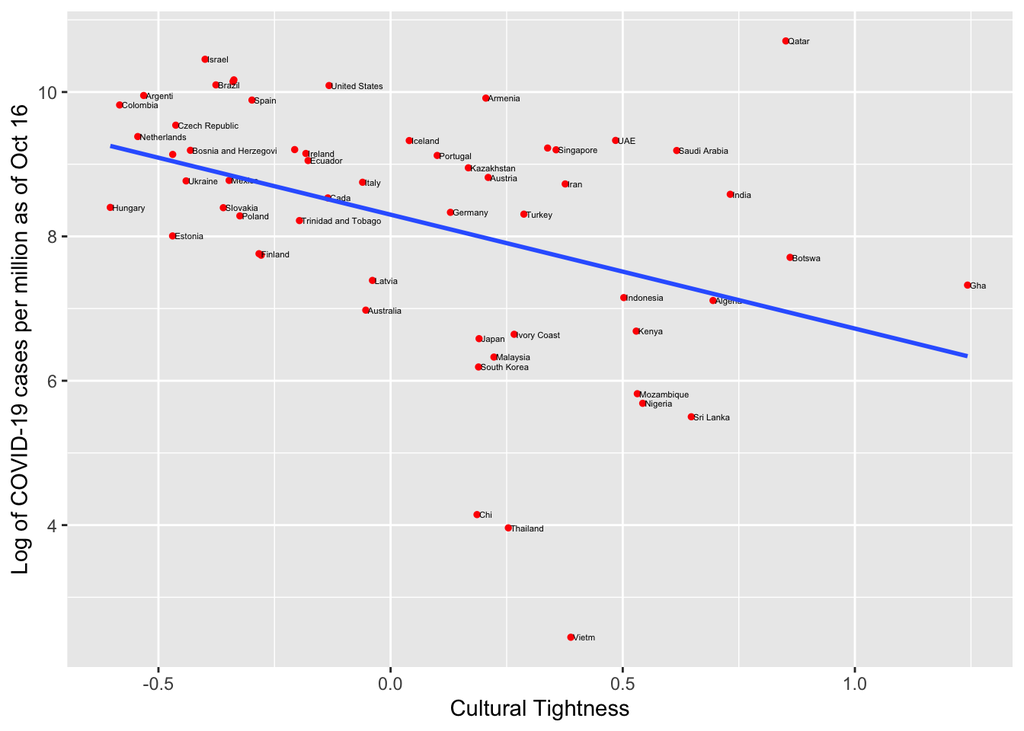

## Reproducing Figue 2

The association of cultural tightness and logged deaths per million (Oct 2020) *the scatterplot doesn’t inlcude any covariates

### Original Figure 2

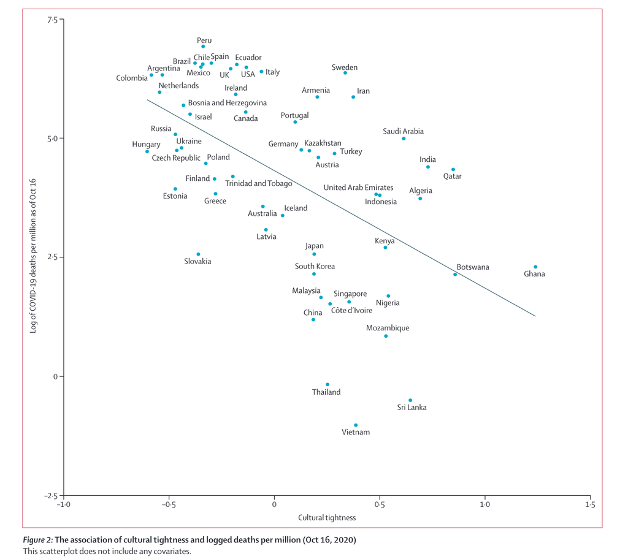

### Reporoduced Figure 2

```
##
##  Pearson's product-moment correlation
##
## data:  data$ZTightness and data$OCTDeaths
## t = -4.7267, df = 55, p-value = 1.625e-05
## alternative hypothesis: true correlation is not equal to 0
## 95 percent confidence interval:
##  -0.7000033 -0.3219960
## sample estimates:
##        cor
## -0.5374691
```

[figure not shown]

## Reproducing Table 1

### Logged сases per million (10 regression models with different covariates)

```
##
## Call:
## lm(formula = (OCTCases) ~ ZTestsPerCaseOct + ZGDP.capita + ZGini +
##     Zlog_PopDensity + ZpercentMigrants + ZGovernment.efficiency,
##     data = data)
##
## Residuals:
##     Min      1Q  Median      3Q     Max
## -3.4526 -0.6822  0.1032  0.8485  2.0921
##
## Coefficients:
##                        Estimate Std. Error t value Pr(>|t|)
## (Intercept)              8.1416     0.1818  44.780  < 2e-16 ***
## ZTestsPerCaseOct        -0.8388     0.1854  -4.524 4.73e-05 ***
## ZGDP.capita              0.8172     0.2713   3.012  0.00433 **
## ZGini                    0.2571     0.2096   1.227  0.22668
## Zlog_PopDensity         -0.1882     0.1914  -0.983  0.33091
## ZpercentMigrants         0.4152     0.2275   1.825  0.07495 .
## ZGovernment.efficiency  -0.5856     0.2568  -2.280  0.02761 *
## ---
## Signif. codes:  0 '***' 0.001 '**' 0.01 '*' 0.05 '.' 0.1 ' ' 1
##
## Residual standard error: 1.275 on 43 degrees of freedom
##   (7 observations deleted due to missingness)
## Multiple R-squared:  0.5486, Adjusted R-squared:  0.4856
## F-statistic:  8.71 on 6 and 43 DF,  p-value: 3.204e-06
```

```
##
## Call:
## lm(formula = (OCTCases) ~ ZTestsPerCaseOct + ZGDP.capita + ZGini +
##     Zlog_PopDensity + ZpercentMigrants + ZGovernment.efficiency +
##     ZTightness, data = data)
##
## Residuals:
##     Min      1Q  Median      3Q     Max
## -3.1358 -0.6274  0.1522  0.6121  2.3845
##
## Coefficients:
##                         Estimate Std. Error t value Pr(>|t|)
## (Intercept)             8.068072   0.158589  50.874  < 2e-16 ***
## ZTestsPerCaseOct       -0.794576   0.160984  -4.936 1.31e-05 ***
## ZGDP.capita             0.442962   0.253644   1.746 0.088053 .
## ZGini                   0.438406   0.187363   2.340 0.024118 *
## Zlog_PopDensity        -0.003823   0.172309  -0.022 0.982404
## ZpercentMigrants        0.583849   0.201687   2.895 0.005995 **
## ZGovernment.efficiency -0.200604   0.243226  -0.825 0.414164
## ZTightness             -0.804345   0.205488  -3.914 0.000326 ***
## ---
## Signif. codes:  0 '***' 0.001 '**' 0.01 '*' 0.05 '.' 0.1 ' ' 1
##
## Residual standard error: 1.104 on 42 degrees of freedom
##   (7 observations deleted due to missingness)
## Multiple R-squared:  0.6693, Adjusted R-squared:  0.6141
## F-statistic: 12.14 on 7 and 42 DF,  p-value: 2.335e-08
```

```
##
## Call:
## lm(formula = (OCTCases) ~ ZOct16_total_tests_per_thousand + ZGDP.capita +
##     ZGini + Zlog_PopDensity + ZpercentMigrants + ZGovernment.efficiency +
##     ZTightness, data = data)
##
## Residuals:
##     Min      1Q  Median      3Q     Max
## -3.8986 -0.4884  0.1448  0.8292  2.9451
##
## Coefficients:
##                                 Estimate Std. Error t value Pr(>|t|)
## (Intercept)                      8.06187    0.19919  40.473  < 2e-16 ***
## ZOct16_total_tests_per_thousand  0.17944    0.34797   0.516  0.60880
## ZGDP.capita                      0.56392    0.32124   1.755  0.08647 .
## ZGini                            0.54548    0.23403   2.331  0.02464 *
## Zlog_PopDensity                 -0.03622    0.21581  -0.168  0.86754
## ZpercentMigrants                 0.55644    0.33978   1.638  0.10897
## ZGovernment.efficiency          -0.34753    0.30324  -1.146  0.25827
## ZTightness                      -0.84512    0.26352  -3.207  0.00257 **
## ---
## Signif. codes:  0 '***' 0.001 '**' 0.01 '*' 0.05 '.' 0.1 ' ' 1
##
## Residual standard error: 1.384 on 42 degrees of freedom
##   (7 observations deleted due to missingness)
## Multiple R-squared:  0.4807, Adjusted R-squared:  0.3941
## F-statistic: 5.554 on 7 and 42 DF,  p-value: 0.0001421
```

```
##
## Call:
## lm(formula = (OCTCases) ~ ZUnderreporting + ZGDP.capita + ZGini +
##     Zlog_PopDensity + ZpercentMigrants + ZGovernment.efficiency +
##     ZTightness, data = data)
##
## Residuals:
##     Min      1Q  Median      3Q     Max
## -4.0915 -0.6480  0.2709  0.7155  2.7213
##
## Coefficients:
##                        Estimate Std. Error t value Pr(>|t|)
## (Intercept)             8.15568    0.20031  40.716  < 2e-16 ***
## ZUnderreporting        -0.03927    0.25483  -0.154  0.87823
## ZGDP.capita             0.48732    0.32525   1.498  0.14120
## ZGini                   0.40317    0.24004   1.680  0.10013
## Zlog_PopDensity        -0.09780    0.22512  -0.434  0.66608
## ZpercentMigrants        0.68480    0.26530   2.581  0.01325 *
## ZGovernment.efficiency -0.38580    0.33317  -1.158  0.25313
## ZTightness             -0.77383    0.25555  -3.028  0.00411 **
## ---
## Signif. codes:  0 '***' 0.001 '**' 0.01 '*' 0.05 '.' 0.1 ' ' 1
##
## Residual standard error: 1.437 on 44 degrees of freedom
##   (5 observations deleted due to missingness)
## Multiple R-squared:  0.4217, Adjusted R-squared:  0.3297
## F-statistic: 4.584 on 7 and 44 DF,  p-value: 0.0006485
```

```
##
## Call:
## lm(formula = (OCTCases) ~ ZLogBeds + ZGDP.capita + ZGini + Zlog_PopDensity +
##     ZpercentMigrants + ZGovernment.efficiency + ZTightness, data = data)
##
## Residuals:
##     Min      1Q  Median      3Q     Max
## -4.1433 -0.5401  0.3104  0.7479  2.7995
##
## Coefficients:
##                        Estimate Std. Error t value Pr(>|t|)
## (Intercept)              8.1774     0.1878  43.543  < 2e-16 ***
## ZLogBeds                -0.2235     0.2586  -0.864  0.39194
## ZGDP.capita              0.5642     0.3207   1.759  0.08505 .
## ZGini                    0.3103     0.2405   1.291  0.20316
## Zlog_PopDensity         -0.1119     0.1967  -0.569  0.57231
## ZpercentMigrants         0.6432     0.2511   2.561  0.01370 *
## ZGovernment.efficiency  -0.4144     0.3024  -1.370  0.17714
## ZTightness              -0.8031     0.2444  -3.286  0.00192 **
## ---
## Signif. codes:  0 '***' 0.001 '**' 0.01 '*' 0.05 '.' 0.1 ' ' 1
##
## Residual standard error: 1.388 on 47 degrees of freedom
##   (2 observations deleted due to missingness)
## Multiple R-squared:  0.4349, Adjusted R-squared:  0.3508
## F-statistic: 5.168 on 7 and 47 DF,  p-value: 0.0002051
```

```
##
## Call:
## lm(formula = (OCTCases) ~ ZTestsPerCaseOct + ZGDP.capita + ZGini +
##     Zlog_PopDensity + ZpercentMigrants + ZGovernment.efficiency +
##     ZTightness + ZCollectivism + ZPowerdistance, data = data)
##
## Residuals:
##     Min      1Q  Median      3Q     Max
## -3.1810 -0.5037  0.1459  0.5940  2.3357
##
## Coefficients:
##                          Estimate Std. Error t value Pr(>|t|)
## (Intercept)             8.0890371  0.1660940  48.702  < 2e-16 ***
## ZTestsPerCaseOct       -0.8086398  0.1671575  -4.838 2.09e-05 ***
## ZGDP.capita             0.4013578  0.3480362   1.153 0.255844
## ZGini                   0.4347617  0.2050665   2.120 0.040413 *
## Zlog_PopDensity        -0.0115470  0.1823172  -0.063 0.949824
## ZpercentMigrants        0.5813706  0.2357139   2.466 0.018147 *
## ZGovernment.efficiency -0.1559249  0.2560917  -0.609 0.546145
## ZTightness             -0.8147489  0.2142279  -3.803 0.000491 ***
## ZCollectivism           0.0200686  0.2677167   0.075 0.940628
## ZPowerdistance         -0.0004635  0.2665703  -0.002 0.998621
## ---
## Signif. codes:  0 '***' 0.001 '**' 0.01 '*' 0.05 '.' 0.1 ' ' 1
##
## Residual standard error: 1.135 on 39 degrees of freedom
##   (8 observations deleted due to missingness)
## Multiple R-squared:  0.6707, Adjusted R-squared:  0.5947
## F-statistic: 8.826 on 9 and 39 DF,  p-value: 4.33e-07
```

```
##
## Call:
## lm(formula = (OCTCases) ~ ZTestsPerCaseOct + ZGDP.capita + ZGini +
##     Zlog_PopDensity + ZpercentMigrants + ZGovernment.efficiency +
##     ZTightness + ZAuthoritarian, data = data)
##
## Residuals:
##     Min      1Q  Median      3Q     Max
## -3.2725 -0.5890  0.1060  0.4758  2.4753
##
## Coefficients:
##                        Estimate Std. Error t value Pr(>|t|)
## (Intercept)              8.0389     0.1633  49.241  < 2e-16 ***
## ZTestsPerCaseOct        -0.8998     0.2039  -4.414  7.5e-05 ***
## ZGDP.capita              0.4317     0.2778   1.554 0.128076
## ZGini                    0.4391     0.1953   2.249 0.030101 *
## Zlog_PopDensity          0.0528     0.1902   0.278 0.782723
## ZpercentMigrants         0.4437     0.2953   1.503 0.140801
## ZGovernment.efficiency  -0.1720     0.2456  -0.700 0.487708
## ZTightness              -0.9037     0.2212  -4.085 0.000206 ***
## ZAuthoritarian           0.2451     0.2857   0.858 0.396099
## ---
## Signif. codes:  0 '***' 0.001 '**' 0.01 '*' 0.05 '.' 0.1 ' ' 1
##
## Residual standard error: 1.11 on 40 degrees of freedom
##   (8 observations deleted due to missingness)
## Multiple R-squared:  0.6789, Adjusted R-squared:  0.6147
## F-statistic: 10.57 on 8 and 40 DF,  p-value: 8.065e-08
```

```
##
## Call:
## lm(formula = (OCTCases) ~ ZTestsPerCaseOct + ZGDP.capita + ZGini +
##     Zlog_PopDensity + ZpercentMigrants + ZGovernment.efficiency +
##     ZTightness + ZMedian_Age, data = data)
##
## Residuals:
##     Min      1Q  Median      3Q     Max
## -3.1258 -0.6144  0.1485  0.6183  2.3833
##
## Coefficients:
##                        Estimate Std. Error t value Pr(>|t|)
## (Intercept)             8.06809    0.16050  50.267  < 2e-16 ***
## ZTestsPerCaseOct       -0.79313    0.16467  -4.816 2.02e-05 ***
## ZGDP.capita             0.44950    0.27843   1.614 0.114114
## ZGini                   0.42972    0.23767   1.808 0.077938 .
## Zlog_PopDensity        -0.00238    0.17601  -0.014 0.989277
## ZpercentMigrants        0.58290    0.20472   2.847 0.006859 **
## ZGovernment.efficiency -0.20304    0.24941  -0.814 0.420308
## ZTightness             -0.80930    0.22348  -3.621 0.000799 ***
## ZMedian_Age            -0.01652    0.27243  -0.061 0.951946
## ---
## Signif. codes:  0 '***' 0.001 '**' 0.01 '*' 0.05 '.' 0.1 ' ' 1
##
## Residual standard error: 1.118 on 41 degrees of freedom
##   (7 observations deleted due to missingness)
## Multiple R-squared:  0.6693, Adjusted R-squared:  0.6048
## F-statistic: 10.37 on 8 and 41 DF,  p-value: 8.58e-08
```

```
##
## Call:
## lm(formula = (OCTCases) ~ ZTestsPerCaseOct + ZGDP.capita + ZGini +
##     Zlog_PopDensity + ZpercentMigrants + ZGovernment.efficiency +
##     ZTightness + Zday_diff, data = data)
##
## Residuals:
##      Min       1Q   Median       3Q      Max
## -1.90840 -0.56295  0.04809  0.53054  1.83453
##
## Coefficients:
##                         Estimate Std. Error t value Pr(>|t|)
## (Intercept)             8.245951   0.169785  48.567  < 2e-16 ***
## ZTestsPerCaseOct       -0.837678   0.145193  -5.769 2.66e-06 ***
## ZGDP.capita             0.283738   0.259250   1.094 0.282465
## ZGini                   0.510889   0.202418   2.524 0.017133 *
## Zlog_PopDensity        -0.040230   0.196399  -0.205 0.839082
## ZpercentMigrants        0.397153   0.224761   1.767 0.087401 .
## ZGovernment.efficiency  0.005205   0.258944   0.020 0.984097
## ZTightness             -0.734152   0.199250  -3.685 0.000901 ***
## Zday_diff              -0.196568   0.165209  -1.190 0.243450
## ---
## Signif. codes:  0 '***' 0.001 '**' 0.01 '*' 0.05 '.' 0.1 ' ' 1
##
## Residual standard error: 0.9844 on 30 degrees of freedom
##   (18 observations deleted due to missingness)
## Multiple R-squared:  0.7513, Adjusted R-squared:  0.685
## F-statistic: 11.33 on 8 and 30 DF,  p-value: 3.17e-07
```

```
##
## Call:
## lm(formula = (OCTCases) ~ ZTestsPerCaseOct + ZGDP.capita + ZGini +
##     Zlog_PopDensity + ZpercentMigrants + ZGovernment.efficiency +
##     ZTightness + ZStringencyIndex, data = data)
##
## Residuals:
##      Min       1Q   Median       3Q      Max
## -2.44283 -0.46602  0.09706  0.60253  1.97464
##
## Coefficients:
##                        Estimate Std. Error t value Pr(>|t|)
## (Intercept)             8.12952    0.14853  54.732  < 2e-16 ***
## ZTestsPerCaseOct       -0.86836    0.14913  -5.823 8.39e-07 ***
## ZGDP.capita             0.49409    0.23246   2.125  0.03978 *
## ZGini                   0.04757    0.21652   0.220  0.82721
## Zlog_PopDensity        -0.01288    0.15789  -0.082  0.93537
## ZpercentMigrants        0.39901    0.19333   2.064  0.04555 *
## ZGovernment.efficiency  0.02631    0.23712   0.111  0.91220
## ZTightness             -0.67653    0.19213  -3.521  0.00109 **
## ZStringencyIndex        0.66351    0.20757   3.196  0.00272 **
## ---
## Signif. codes:  0 '***' 0.001 '**' 0.01 '*' 0.05 '.' 0.1 ' ' 1
##
## Residual standard error: 1.01 on 40 degrees of freedom
##   (8 observations deleted due to missingness)
## Multiple R-squared:  0.7366, Adjusted R-squared:  0.6839
## F-statistic: 13.98 on 8 and 40 DF,  p-value: 1.927e-09
```

### Creating table with all 10 models

|  | Model 1 |  |  | Model 2 |  |  | Model 3 |  |  | Model 4 |  |  | Model 5 |  |  | Model 6 |  |  | Model 7 |  |  | Model 8 |  |  | Model 9 |  |  | Model 10 |  | … |
| --- | --- | --- | --- | --- | --- | --- | --- | --- | --- | --- | --- | --- | --- | --- | --- | --- | --- | --- | --- | --- | --- | --- | --- | --- | --- | --- | --- | --- | --- | --- |
| Predictors | Estimates | CI | p | Estimates | CI | p | Estimates | CI | p | Estimates | CI | p | Estimates | CI | p | Estimates | CI | p | Estimates | CI | p | Estimates | CI | p | Estimates | CI | p | Estimates | CI | … |
| (Intercept) | 8.14 | 7.77 – 8.51 | **<0.001** | 8.07 | 7.75 – 8.39 | **<0.001** | 8.06 | 7.66 – 8.46 | **<0.001** | 8.16 | 7.75 – 8.56 | **<0.001** | 8.18 | 7.80 – 8.56 | **<0.001** | 8.09 | 7.75 – 8.42 | **<0.001** | 8.04 | 7.71 – 8.37 | **<0.001** | 8.07 | 7.74 – 8.39 | **<0.001** | 8.25 | 7.90 – 8.59 | **<0.001** | 8.13 | 7.83 – 8.43 | … |
| ZTestsPerCaseOct | -0.84 | -1.21 – -0.46 | **<0.001** | -0.79 | -1.12 – -0.47 | **<0.001** |  |  |  |  |  |  |  |  |  | -0.81 | -1.15 – -0.47 | **<0.001** | -0.90 | -1.31 – -0.49 | **<0.001** | -0.79 | -1.13 – -0.46 | **<0.001** | -0.84 | -1.13 – -0.54 | **<0.001** | -0.87 | -1.17 – -0.57 | … |
| ZGDP capita | 0.82 | 0.27 – 1.36 | **0.004** | 0.44 | -0.07 – 0.95 | 0.088 | 0.56 | -0.08 – 1.21 | 0.086 | 0.49 | -0.17 – 1.14 | 0.141 | 0.56 | -0.08 – 1.21 | 0.085 | 0.40 | -0.30 – 1.11 | 0.256 | 0.43 | -0.13 – 0.99 | 0.128 | 0.45 | -0.11 – 1.01 | 0.114 | 0.28 | -0.25 – 0.81 | 0.282 | 0.49 | 0.02 – 0.96 | … |
| ZGini | 0.26 | -0.17 – 0.68 | 0.227 | 0.44 | 0.06 – 0.82 | **0.024** | 0.55 | 0.07 – 1.02 | **0.025** | 0.40 | -0.08 – 0.89 | 0.100 | 0.31 | -0.17 – 0.79 | 0.203 | 0.43 | 0.02 – 0.85 | **0.040** | 0.44 | 0.04 – 0.83 | **0.030** | 0.43 | -0.05 – 0.91 | 0.078 | 0.51 | 0.10 – 0.92 | **0.017** | 0.05 | -0.39 – 0.49 | … |
| Zlog PopDensity | -0.19 | -0.57 – 0.20 | 0.331 | -0.00 | -0.35 – 0.34 | 0.982 | -0.04 | -0.47 – 0.40 | 0.868 | -0.10 | -0.55 – 0.36 | 0.666 | -0.11 | -0.51 – 0.28 | 0.572 | -0.01 | -0.38 – 0.36 | 0.950 | 0.05 | -0.33 – 0.44 | 0.783 | -0.00 | -0.36 – 0.35 | 0.989 | -0.04 | -0.44 – 0.36 | 0.839 | -0.01 | -0.33 – 0.31 | … |
| ZpercentMigrants | 0.42 | -0.04 – 0.87 | 0.075 | 0.58 | 0.18 – 0.99 | **0.006** | 0.56 | -0.13 – 1.24 | 0.109 | 0.68 | 0.15 – 1.22 | **0.013** | 0.64 | 0.14 – 1.15 | **0.014** | 0.58 | 0.10 – 1.06 | **0.018** | 0.44 | -0.15 – 1.04 | 0.141 | 0.58 | 0.17 – 1.00 | **0.007** | 0.40 | -0.06 – 0.86 | 0.087 | 0.40 | 0.01 – 0.79 | … |
| ZGovernment efficiency | -0.59 | -1.10 – -0.07 | **0.028** | -0.20 | -0.69 – 0.29 | 0.414 | -0.35 | -0.96 – 0.26 | 0.258 | -0.39 | -1.06 – 0.29 | 0.253 | -0.41 | -1.02 – 0.19 | 0.177 | -0.16 | -0.67 – 0.36 | 0.546 | -0.17 | -0.67 – 0.32 | 0.488 | -0.20 | -0.71 – 0.30 | 0.420 | 0.01 | -0.52 – 0.53 | 0.984 | 0.03 | -0.45 – 0.51 | … |
| ZTightness |  |  |  | -0.80 | -1.22 – -0.39 | **<0.001** | -0.85 | -1.38 – -0.31 | **0.003** | -0.77 | -1.29 – -0.26 | **0.004** | -0.80 | -1.29 – -0.31 | **0.002** | -0.81 | -1.25 – -0.38 | **<0.001** | -0.90 | -1.35 – -0.46 | **<0.001** | -0.81 | -1.26 – -0.36 | **0.001** | -0.73 | -1.14 – -0.33 | **0.001** | -0.68 | -1.06 – -0.29 | … |
| ZOct16 total tests per thousand |  |  |  |  |  |  | 0.18 | -0.52 – 0.88 | 0.609 |  |  |  |  |  |  |  |  |  |  |  |  |  |  |  |  |  |  |  |  | … |
| ZUnderreporting |  |  |  |  |  |  |  |  |  | -0.04 | -0.55 – 0.47 | 0.878 |  |  |  |  |  |  |  |  |  |  |  |  |  |  |  |  |  | … |
| ZLogBeds |  |  |  |  |  |  |  |  |  |  |  |  | -0.22 | -0.74 – 0.30 | 0.392 |  |  |  |  |  |  |  |  |  |  |  |  |  |  | … |
| ZCollectivism |  |  |  |  |  |  |  |  |  |  |  |  |  |  |  | 0.02 | -0.52 – 0.56 | 0.941 |  |  |  |  |  |  |  |  |  |  |  | … |
| ZPowerdistance |  |  |  |  |  |  |  |  |  |  |  |  |  |  |  | -0.00 | -0.54 – 0.54 | 0.999 |  |  |  |  |  |  |  |  |  |  |  | … |
| ZAuthoritarian |  |  |  |  |  |  |  |  |  |  |  |  |  |  |  |  |  |  | 0.25 | -0.33 – 0.82 | 0.396 |  |  |  |  |  |  |  |  | … |
| ZMedian Age |  |  |  |  |  |  |  |  |  |  |  |  |  |  |  |  |  |  |  |  |  | -0.02 | -0.57 – 0.53 | 0.952 |  |  |  |  |  | … |
| Zday diff |  |  |  |  |  |  |  |  |  |  |  |  |  |  |  |  |  |  |  |  |  |  |  |  | -0.20 | -0.53 – 0.14 | 0.243 |  |  | … |
| ZStringencyIndex |  |  |  |  |  |  |  |  |  |  |  |  |  |  |  |  |  |  |  |  |  |  |  |  |  |  |  | 0.66 | 0.24 – 1.08 | … |
| Observations | 50 |  |  | 50 |  |  | 50 |  |  | 52 |  |  | 55 |  |  | 49 |  |  | 49 |  |  | 50 |  |  | 39 |  |  | 49 |  | … |
| R<sup>2</sup> / R<sup>2</sup> adjusted | 0.549 / 0.486 |  |  | 0.669 / 0.614 |  |  | 0.481 / 0.394 |  |  | 0.422 / 0.330 |  |  | 0.435 / 0.351 |  |  | 0.671 / 0.595 |  |  | 0.679 / 0.615 |  |  | 0.669 / 0.605 |  |  | 0.751 / 0.685 |  |  | 0.737 / 0.684 |  | … |

## Reproducing Table 2

### Logged deaths per million (7 regression models with different covariats)

```
##
## Call:
## lm(formula = OCTDeaths ~ ZMortality + ZGDP.capita + ZGini + Zlog_PopDensity +
##     ZpercentMigrants + ZGovernment.efficiency, data = data)
##
## Residuals:
##     Min      1Q  Median      3Q     Max
## -4.0178 -1.1716  0.2331  1.0690  3.0818
##
## Coefficients:
##                        Estimate Std. Error t value Pr(>|t|)
## (Intercept)              4.1668     0.2458  16.955  < 2e-16 ***
## ZMortality              -0.0366     0.3143  -0.116  0.90778
## ZGDP.capita              1.1428     0.3701   3.087  0.00335 **
## ZGini                    0.1793     0.3090   0.580  0.56446
## Zlog_PopDensity         -0.4098     0.2547  -1.609  0.11415
## ZpercentMigrants         0.1656     0.3389   0.489  0.62720
## ZGovernment.efficiency  -1.1374     0.3567  -3.189  0.00252 **
## ---
## Signif. codes:  0 '***' 0.001 '**' 0.01 '*' 0.05 '.' 0.1 ' ' 1
##
## Residual standard error: 1.818 on 48 degrees of freedom
##   (2 observations deleted due to missingness)
## Multiple R-squared:  0.2763, Adjusted R-squared:  0.1858
## F-statistic: 3.054 on 6 and 48 DF,  p-value: 0.01302
```

```
##
## Call:
## lm(formula = OCTDeaths ~ ZMortality + ZGDP.capita + ZGini + Zlog_PopDensity +
##     ZpercentMigrants + ZGovernment.efficiency + ZTightness, data = data)
##
## Residuals:
##     Min      1Q  Median      3Q     Max
## -3.7123 -0.7007  0.1193  1.1466  3.0474
##
## Coefficients:
##                        Estimate Std. Error t value Pr(>|t|)
## (Intercept)              4.1339     0.2171  19.043  < 2e-16 ***
## ZMortality              -0.3113     0.2866  -1.086 0.282846
## ZGDP.capita              0.5438     0.3623   1.501 0.140044
## ZGini                    0.2575     0.2735   0.941 0.351317
## Zlog_PopDensity         -0.2764     0.2275  -1.215 0.230402
## ZpercentMigrants         0.2720     0.3004   0.906 0.369773
## ZGovernment.efficiency  -0.5779     0.3471  -1.665 0.102589
## ZTightness              -1.0731     0.2806  -3.824 0.000386 ***
## ---
## Signif. codes:  0 '***' 0.001 '**' 0.01 '*' 0.05 '.' 0.1 ' ' 1
##
## Residual standard error: 1.604 on 47 degrees of freedom
##   (2 observations deleted due to missingness)
## Multiple R-squared:  0.448,  Adjusted R-squared:  0.3658
## F-statistic: 5.449 on 7 and 47 DF,  p-value: 0.0001266
```

```
##
## Call:
## lm(formula = OCTDeaths ~ ZMortality + ZGDP.capita + ZGini + Zlog_PopDensity +
##     ZpercentMigrants + ZGovernment.efficiency + ZTightness +
##     ZCollectivism + ZPowerdistance, data = data)
##
## Residuals:
##     Min      1Q  Median      3Q     Max
## -3.4340 -0.9497  0.1392  1.1454  2.5805
##
## Coefficients:
##                        Estimate Std. Error t value Pr(>|t|)
## (Intercept)             4.09674    0.22978  17.829  < 2e-16 ***
## ZMortality             -0.35424    0.32843  -1.079 0.287234
## ZGDP.capita             0.08006    0.48968   0.163 0.870955
## ZGini                   0.57615    0.31478   1.830 0.074655 .
## Zlog_PopDensity        -0.15407    0.25407  -0.606 0.547687
## ZpercentMigrants        0.45199    0.33651   1.343 0.186791
## ZGovernment.efficiency -0.42270    0.35824  -1.180 0.244997
## ZTightness             -1.08025    0.29929  -3.609 0.000845 ***
## ZCollectivism          -0.50291    0.38544  -1.305 0.199429
## ZPowerdistance         -0.23634    0.36249  -0.652 0.518131
## ---
## Signif. codes:  0 '***' 0.001 '**' 0.01 '*' 0.05 '.' 0.1 ' ' 1
##
## Residual standard error: 1.582 on 40 degrees of freedom
##   (7 observations deleted due to missingness)
## Multiple R-squared:  0.5059, Adjusted R-squared:  0.3948
## F-statistic: 4.551 on 9 and 40 DF,  p-value: 0.0003639
```

```
##
## Call:
## lm(formula = OCTDeaths ~ ZMortality + ZGDP.capita + ZGini + Zlog_PopDensity +
##     ZpercentMigrants + ZGovernment.efficiency + ZTightness +
##     ZAuthoritarian, data = data)
##
## Residuals:
##     Min      1Q  Median      3Q     Max
## -3.1940 -0.6667 -0.0748  1.1332  2.8496
##
## Coefficients:
##                        Estimate Std. Error t value Pr(>|t|)
## (Intercept)              4.1612     0.2223  18.718  < 2e-16 ***
## ZMortality              -0.4806     0.3009  -1.597  0.11746
## ZGDP.capita              0.5567     0.3952   1.408  0.16604
## ZGini                    0.1639     0.2804   0.584  0.56201
## Zlog_PopDensity         -0.3448     0.2451  -1.407  0.16659
## ZpercentMigrants         0.4400     0.3702   1.188  0.24101
## ZGovernment.efficiency  -0.6048     0.3479  -1.739  0.08908 .
## ZTightness              -0.9467     0.2875  -3.293  0.00196 **
## ZAuthoritarian          -0.4257     0.3324  -1.281  0.20696
## ---
## Signif. codes:  0 '***' 0.001 '**' 0.01 '*' 0.05 '.' 0.1 ' ' 1
##
## Residual standard error: 1.596 on 44 degrees of freedom
##   (4 observations deleted due to missingness)
## Multiple R-squared:  0.4814, Adjusted R-squared:  0.3871
## F-statistic: 5.105 on 8 and 44 DF,  p-value: 0.0001578
```

```
##
## Call:
## lm(formula = OCTDeaths ~ ZMortality + ZGDP.capita + ZGini + Zlog_PopDensity +
##     ZpercentMigrants + ZGovernment.efficiency + ZTightness +
##     ZMedian_Age, data = data)
##
## Residuals:
##     Min      1Q  Median      3Q     Max
## -3.7083 -0.7873  0.0605  1.1228  3.0614
##
## Coefficients:
##                        Estimate Std. Error t value Pr(>|t|)
## (Intercept)              4.1321     0.2190  18.867  < 2e-16 ***
## ZMortality              -0.3615     0.3114  -1.161  0.25166
## ZGDP.capita              0.4735     0.3998   1.184  0.24242
## ZGini                    0.3195     0.3108   1.028  0.30933
## Zlog_PopDensity         -0.2890     0.2313  -1.250  0.21779
## ZpercentMigrants         0.2698     0.3030   0.890  0.37786
## ZGovernment.efficiency  -0.5628     0.3519  -1.599  0.11659
## ZTightness              -1.0302     0.2998  -3.436  0.00126 **
## ZMedian_Age              0.1750     0.4038   0.433  0.66668
## ---
## Signif. codes:  0 '***' 0.001 '**' 0.01 '*' 0.05 '.' 0.1 ' ' 1
##
## Residual standard error: 1.618 on 46 degrees of freedom
##   (2 observations deleted due to missingness)
## Multiple R-squared:  0.4502, Adjusted R-squared:  0.3546
## F-statistic: 4.709 on 8 and 46 DF,  p-value: 0.000293
```

```
##
## Call:
## lm(formula = OCTDeaths ~ ZMortality + ZGDP.capita + ZGini + Zlog_PopDensity +
##     ZpercentMigrants + ZGovernment.efficiency + ZTightness +
##     Zday_diff, data = data)
##
## Residuals:
##     Min      1Q  Median      3Q     Max
## -3.8077 -0.7218  0.0020  1.0257  2.8610
##
## Coefficients:
##                        Estimate Std. Error t value Pr(>|t|)
## (Intercept)             4.34691    0.24493  17.747  < 2e-16 ***
## ZMortality             -0.27334    0.35125  -0.778  0.44183
## ZGDP.capita             0.68647    0.39753   1.727  0.09328 .
## ZGini                   0.23521    0.31218   0.753  0.45637
## Zlog_PopDensity        -0.41116    0.26310  -1.563  0.12737
## ZpercentMigrants        0.07437    0.36249   0.205  0.83867
## ZGovernment.efficiency -0.59319    0.39140  -1.516  0.13887
## ZTightness             -0.94445    0.28456  -3.319  0.00216 **
## Zday_diff              -0.12308    0.25505  -0.483  0.63249
## ---
## Signif. codes:  0 '***' 0.001 '**' 0.01 '*' 0.05 '.' 0.1 ' ' 1
##
## Residual standard error: 1.532 on 34 degrees of freedom
##   (14 observations deleted due to missingness)
## Multiple R-squared:  0.525,  Adjusted R-squared:  0.4133
## F-statistic: 4.698 on 8 and 34 DF,  p-value: 0.0006129
```

```
##
## Call:
## lm(formula = OCTDeaths ~ ZMortality + ZGDP.capita + ZGini + Zlog_PopDensity +
##     ZpercentMigrants + ZGovernment.efficiency + ZTightness +
##     ZStringencyIndex, data = data)
##
## Residuals:
##     Min      1Q  Median      3Q     Max
## -3.6742 -0.7724  0.1668  0.8906  3.2502
##
## Coefficients:
##                        Estimate Std. Error t value Pr(>|t|)
## (Intercept)             4.16224    0.20199  20.606  < 2e-16 ***
## ZMortality             -0.10707    0.28435  -0.377 0.708308
## ZGDP.capita             0.72544    0.33349   2.175 0.035024 *
## ZGini                  -0.04967    0.27405  -0.181 0.857011
## Zlog_PopDensity        -0.27065    0.20693  -1.308 0.197687
## ZpercentMigrants        0.13835    0.27675   0.500 0.619640
## ZGovernment.efficiency -0.37399    0.34392  -1.087 0.282778
## ZTightness             -0.95524    0.26195  -3.647 0.000699 ***
## ZStringencyIndex        0.75106    0.29982   2.505 0.016020 *
## ---
## Signif. codes:  0 '***' 0.001 '**' 0.01 '*' 0.05 '.' 0.1 ' ' 1
##
## Residual standard error: 1.457 on 44 degrees of freedom
##   (4 observations deleted due to missingness)
## Multiple R-squared:  0.5627, Adjusted R-squared:  0.4832
## F-statistic: 7.078 on 8 and 44 DF,  p-value: 5.67e-06
```

### Creating table with all 7 models

|  | Model 1 |  |  | Model 2 |  |  | Model 3 |  |  | Model 4 |  |  | Model 5 |  |  | Model 6 |  |  | Model 7 |  |  |
| --- | --- | --- | --- | --- | --- | --- | --- | --- | --- | --- | --- | --- | --- | --- | --- | --- | --- | --- | --- | --- | --- |
| Predictors | Estimates | CI | p | Estimates | CI | p | Estimates | CI | p | Estimates | CI | p | Estimates | CI | p | Estimates | CI | p | Estimates | CI | p |
| (Intercept) | 4.17 | 3.67 – 4.66 | **<0.001** | 4.13 | 3.70 – 4.57 | **<0.001** | 4.10 | 3.63 – 4.56 | **<0.001** | 4.16 | 3.71 – 4.61 | **<0.001** | 4.13 | 3.69 – 4.57 | **<0.001** | 4.35 | 3.85 – 4.84 | **<0.001** | 4.16 | 3.76 – 4.57 | **<0.001** |
| ZMortality | -0.04 | -0.67 – 0.60 | 0.908 | -0.31 | -0.89 – 0.27 | 0.283 | -0.35 | -1.02 – 0.31 | 0.287 | -0.48 | -1.09 – 0.13 | 0.117 | -0.36 | -0.99 – 0.27 | 0.252 | -0.27 | -0.99 – 0.44 | 0.442 | -0.11 | -0.68 – 0.47 | 0.708 |
| ZGDP capita | 1.14 | 0.40 – 1.89 | **0.003** | 0.54 | -0.19 – 1.27 | 0.140 | 0.08 | -0.91 – 1.07 | 0.871 | 0.56 | -0.24 – 1.35 | 0.166 | 0.47 | -0.33 – 1.28 | 0.242 | 0.69 | -0.12 – 1.49 | 0.093 | 0.73 | 0.05 – 1.40 | **0.035** |
| ZGini | 0.18 | -0.44 – 0.80 | 0.564 | 0.26 | -0.29 – 0.81 | 0.351 | 0.58 | -0.06 – 1.21 | 0.075 | 0.16 | -0.40 – 0.73 | 0.562 | 0.32 | -0.31 – 0.95 | 0.309 | 0.24 | -0.40 – 0.87 | 0.456 | -0.05 | -0.60 – 0.50 | 0.857 |
| Zlog PopDensity | -0.41 | -0.92 – 0.10 | 0.114 | -0.28 | -0.73 – 0.18 | 0.230 | -0.15 | -0.67 – 0.36 | 0.548 | -0.34 | -0.84 – 0.15 | 0.167 | -0.29 | -0.75 – 0.18 | 0.218 | -0.41 | -0.95 – 0.12 | 0.127 | -0.27 | -0.69 – 0.15 | 0.198 |
| ZpercentMigrants | 0.17 | -0.52 – 0.85 | 0.627 | 0.27 | -0.33 – 0.88 | 0.370 | 0.45 | -0.23 – 1.13 | 0.187 | 0.44 | -0.31 – 1.19 | 0.241 | 0.27 | -0.34 – 0.88 | 0.378 | 0.07 | -0.66 – 0.81 | 0.839 | 0.14 | -0.42 – 0.70 | 0.620 |
| ZGovernment efficiency | -1.14 | -1.85 – -0.42 | **0.003** | -0.58 | -1.28 – 0.12 | 0.103 | -0.42 | -1.15 – 0.30 | 0.245 | -0.60 | -1.31 – 0.10 | 0.089 | -0.56 | -1.27 – 0.15 | 0.117 | -0.59 | -1.39 – 0.20 | 0.139 | -0.37 | -1.07 – 0.32 | 0.283 |
| ZTightness |  |  |  | -1.07 | -1.64 – -0.51 | **<0.001** | -1.08 | -1.69 – -0.48 | **0.001** | -0.95 | -1.53 – -0.37 | **0.002** | -1.03 | -1.63 – -0.43 | **0.001** | -0.94 | -1.52 – -0.37 | **0.002** | -0.96 | -1.48 – -0.43 | **0.001** |
| ZCollectivism |  |  |  |  |  |  | -0.50 | -1.28 – 0.28 | 0.199 |  |  |  |  |  |  |  |  |  |  |  |  |
| ZPowerdistance |  |  |  |  |  |  | -0.24 | -0.97 – 0.50 | 0.518 |  |  |  |  |  |  |  |  |  |  |  |  |
| ZAuthoritarian |  |  |  |  |  |  |  |  |  | -0.43 | -1.10 – 0.24 | 0.207 |  |  |  |  |  |  |  |  |  |
| ZMedian Age |  |  |  |  |  |  |  |  |  |  |  |  | 0.18 | -0.64 – 0.99 | 0.667 |  |  |  |  |  |  |
| Zday diff |  |  |  |  |  |  |  |  |  |  |  |  |  |  |  | -0.12 | -0.64 – 0.40 | 0.632 |  |  |  |
| ZStringencyIndex |  |  |  |  |  |  |  |  |  |  |  |  |  |  |  |  |  |  | 0.75 | 0.15 – 1.36 | **0.016** |
| Observations | 55 |  |  | 55 |  |  | 50 |  |  | 53 |  |  | 55 |  |  | 43 |  |  | 53 |  |  |
| R<sup>2</sup> / R<sup>2</sup> adjusted | 0.276 / 0.186 |  |  | 0.448 / 0.366 |  |  | 0.506 / 0.395 |  |  | 0.481 / 0.387 |  |  | 0.450 / 0.355 |  |  | 0.525 / 0.413 |  |  | 0.563 / 0.483 |  |  |

## Discussion and reflection

Overall, my data replication project was very successful and I was able to replicate the models as well as the plots. Interestingly, the open-access code for the figures didn’t actually produce the plot they had in the paper, but I was able to use some of the ggplot features and create an almost identical graph.

Otherwise, I found the replication project relatively easy, since the data was already cleaned and well organized, which I personally find the hardest part of data analysis.